# Coursera/JHU - Practical Machine Learning Course Project

Richard Ferro

5/26/2019

## Overview

This is the final report for Coursera/JHU Practical Machine Learning course which is part of the Specialization in Data Science. The project is peer assessed, is constructed with RStudio using the knitr functions, and is published in html format.

The assignment is to predict the manner of how the participant’s did their exercises. The results will be applied to the 20 tests cases available in the test data and the resulting predictions are use to perform the Course Project Prediction Quiz that is automated grading.

## Background

Using devices such as Jawbone Up, Nike FuelBand, and Fitbit it is now possible to collect a large amount of data about personal activity relatively inexpensively. These type of devices are part of the quantified self movement - a group of enthusiasts who take measurements about themselves regularly to improve their health, to find patterns in their behavior, or because they are tech geeks. One thing that people regularly do is quantify how much of a particular activity they do, but they rarely quantify how well they do it. In this project, your goal will be to use data from accelerometers on the belt, forearm, arm, and dumbell of 6 participants. They were asked to perform barbell lifts correctly and incorrectly in 5 different ways. More information is available from the website here: http://groupware.les.inf.puc-rio.br/har (see the section on the Weight Lifting Exercise Dataset).

Read more: http://groupware.les.inf.puc-rio.br/har#ixzz3xsbS5bVX

## Libraries

```r
library(knitr)
```

```r
library(rpart)
library(rpart.plot)
library(randomForest)
library(rattle)
library(gbm)
library(caret)
library(corrplot)
```

## Getting, Cleaning, and Preparing the Data

```r
#read in the data
TrainData <- read.csv(url("https://d396qusza40orc.cloudfront.net/predmachlearn/pml-training.csv"),header=TRUE)
dim(TrainData)
```

```
## [1] 19622   160
```

```r
TestData <- read.csv(url("https://d396qusza40orc.cloudfront.net/predmachlearn/pml-testing.csv"),header=TRUE)
dim(TestData)
```

```
## [1]  20 160
```

```r
str(TrainData)
```

```
## 'data.frame':    19622 obs. of  160 variables:
##  $ X                       : int  1 2 3 4 5 6 7 8 9 10 ...
##  $ user_name               : Factor w/ 6 levels "adelmo","carlitos",..: 2 2 2 2 2 2 2 2 2 2 ...
##  $ raw_timestamp_part_1    : int  1323084231 1323084231 1323084231 1323084232 1323084232 1323084232 1323084232 1323084232 1323084232 1323084232 ...
##  $ raw_timestamp_part_2    : int  788290 808298 820366 120339 196328 304277 368296 440390 484323 484434 ...
##  $ cvtd_timestamp          : Factor w/ 20 levels "02/12/2011 13:32",..: 9 9 9 9 9 9 9 9 9 9 ...
##  $ new_window              : Factor w/ 2 levels "no","yes": 1 1 1 1 1 1 1 1 1 1 ...
##  $ num_window              : int  11 11 11 12 12 12 12 12 12 12 ...
##  $ roll_belt               : num  1.41 1.41 1.42 1.48 1.48 1.45 1.42 1.42 1.43 1.45 ...
##  $ pitch_belt              : num  8.07 8.07 8.07 8.05 8.07 8.06 8.09 8.13 8.16 8.17 ...
##  $ yaw_belt                : num  -94.4 -94.4 -94.4 -94.4 -94.4 -94.4 -94.4 -94.4 -94.4 -94.4 ...
##  $ total_accel_belt        : int  3 3 3 3 3 3 3 3 3 3 ...
##  $ kurtosis_roll_belt      : Factor w/ 397 levels "","-0.016850",..: 1 1 1 1 1 1 1 1 1 1 ...
##  $ kurtosis_picth_belt     : Factor w/ 317 levels "","-0.021887",..: 1 1 1 1 1 1 1 1 1 1 ...
##  $ kurtosis_yaw_belt       : Factor w/ 2 levels "","#DIV/0!": 1 1 1 1 1 1 1 1 1 1 ...
```

[output cut: 86 more lines]

Both both data sets have 160 variables. The training set has a 19622 observations and the test data set has 20 observations.

```r
#remove NAs
ClnTrainData<- TrainData[, colSums(is.na(TrainData)) == 0]
dim(ClnTrainData)
```

```
## [1] 19622    93
```

```r
ClnTestData<- TestData[, colSums(is.na(TestData)) == 0]
dim(ClnTestData)
```

```
## [1] 20 60
```

After removing NA values the training data set has 19622 observations and 93 columns and the testing data set has 20 observations with 60 columns. Many columns have NA values or blank values for most observations. Next these columns are removed.

```r
#remove first seven columns
ClnTrainData1 <- ClnTrainData[, -c(1:7)]
dim(ClnTrainData1)
```

```
## [1] 19622    86
```

```r
ClnTestData1 <- ClnTestData[, -c(1:7)]
dim(ClnTestData1)
```

```
## [1] 20 53
```

The cleaned training data set is partitioned 70% into a new training data set, Train1, and 30% into a new testing data set, Test1.

```r
# Partitioning the data data
set.seed(1234)
inTrain <- createDataPartition(ClnTrainData1$classe, p = 0.7, list = FALSE)
Train1 <- ClnTrainData1[inTrain,]
Test1 <- ClnTrainData1[-inTrain, ]

dim(Train1)
```

```
## [1] 13737    86
```

```r
dim(Test1)
```

```
## [1] 5885   86
```

Next the data is furthered prepared for predictive modeling by cleaning the data of the variables with Near-Zero Variances.

# Cleaning Data further by Removing the Variables with Near-Zero Variances

```r
NZV <- nearZeroVar(Train1)
train <- Train1[, -NZV]
test  <- Test1[, -NZV]
dim(train)
```

```
## [1] 13737    53
```

```r
dim(test)
```

```
## [1] 5885   53
```

## Correlation Analysis

A correlation among variables is analysed before proceeding to the predictive modeling.

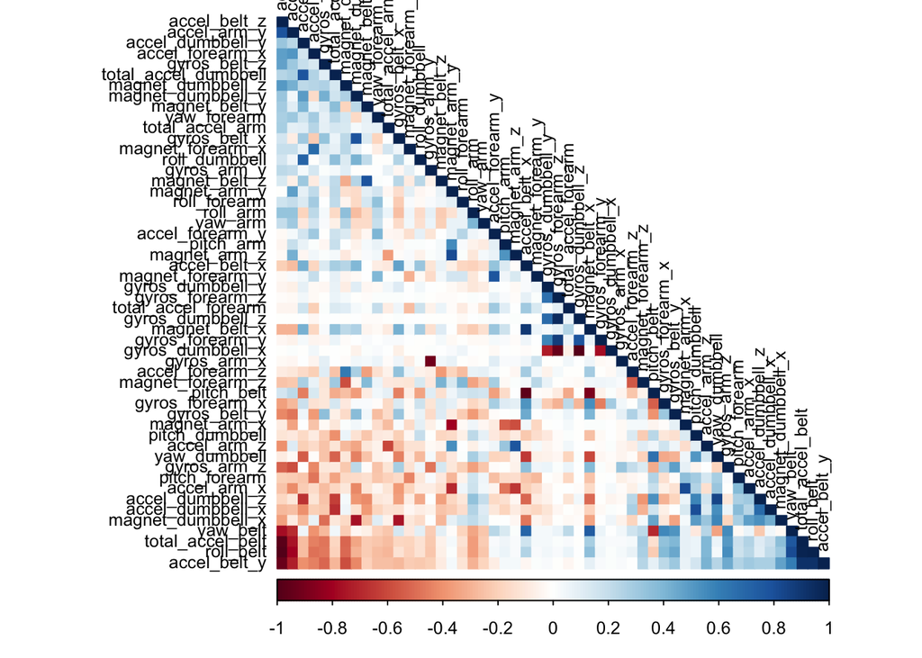

```r
corMatrix <- cor(train[, -53])
corrplot(corMatrix, order = "FPC", method = "color", type = "lower", tl.cex = 0.8, tl.col = rgb(0, 0, 0))
```

In the corrplot graph the dark color intersections indicate the correlated predictors. The findCorrelation function is used to obtain the names of the correlated variables. The cutoff was set to 0.75.

```r
highCorr = findCorrelation(corMatrix, cutoff=0.75)
names(train)[highCorr]
```

```
##  [1] "accel_belt_z"      "roll_belt"         "accel_belt_y"
##  [4] "total_accel_belt"  "accel_dumbbell_z"  "accel_belt_x"
##  [7] "pitch_belt"        "magnet_dumbbell_x" "accel_dumbbell_y"
## [10] "magnet_dumbbell_y" "accel_dumbbell_x"  "accel_arm_x"
## [13] "accel_arm_z"       "magnet_arm_y"      "magnet_belt_z"
## [16] "accel_forearm_y"   "gyros_forearm_y"   "gyros_dumbbell_x"
## [19] "gyros_dumbbell_z"  "gyros_arm_x"
```

## Prediction Model Building

Three prediction methods will be applied to model the regressions in the Train dataset. Decision Tree, Random Forests, and Generalized Boosted Model.

# Decision Tree

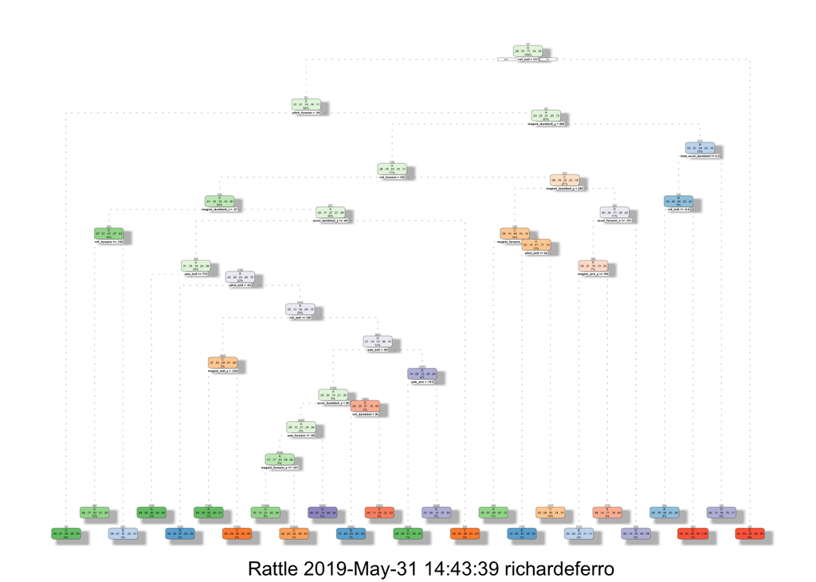

```r
set.seed(12345)
decisionTree <- rpart(classe ~ ., data=train, method="class")
fancyRpartPlot(decisionTree)
```

The decision tree model is validated using the test data to find out how well it performs by determining the accuracy.

```r
predictionTree <- predict(decisionTree, test, type = "class")
CM_decisionTree <- confusionMatrix(predictionTree, test$classe)
CM_decisionTree
```

```
## Confusion Matrix and Statistics
##
##           Reference
## Prediction    A    B    C    D    E
##          A 1522  167   12   49   13
##          B   58  706  100   79   96
##          C   47  109  819  148  139
##          D   25   94   67  609   52
##          E   22   63   28   79  782
##
## Overall Statistics
##
##                Accuracy : 0.7541
##                  95% CI : (0.7429, 0.7651)
##     No Information Rate : 0.2845
##     P-Value [Acc > NIR] : < 2.2e-16
##
##                   Kappa : 0.6885
##
##  Mcnemar's Test P-Value : < 2.2e-16
##
## Statistics by Class:
##
##                      Class: A Class: B Class: C Class: D Class: E
## Sensitivity            0.9092   0.6198   0.7982   0.6317   0.7227
## Specificity            0.9428   0.9298   0.9088   0.9516   0.9600
## Pos Pred Value         0.8633   0.6795   0.6490   0.7190   0.8029
## Neg Pred Value         0.9631   0.9106   0.9552   0.9295   0.9389
## Prevalence             0.2845   0.1935   0.1743   0.1638   0.1839
## Detection Rate         0.2586   0.1200   0.1392   0.1035   0.1329
## Detection Prevalence   0.2996   0.1766   0.2144   0.1439   0.1655
## Balanced Accuracy      0.9260   0.7748   0.8535   0.7917   0.8414
```

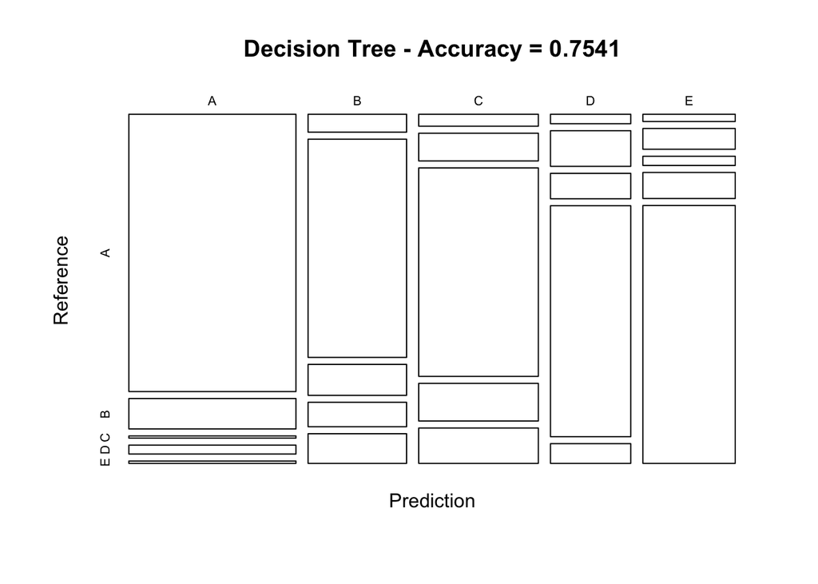

```r
#plot confusion matrix results
plot(CM_decisionTree$table, col = CM_decisionTree$byClass,
     main = paste("Decision Tree - Accuracy =", round(CM_decisionTree$overall['Accuracy'], 4)))
```

# RandomForest

```r
set.seed(12345)
train1=train
controlRF <- trainControl(method="cv", number=3, verboseIter=FALSE)
randomForest <- train(classe ~ ., data=train, method="rf", trControl=controlRF)
randomForest$finalModel
```

```
##
## Call:
##  randomForest(x = x, y = y, mtry = param$mtry)
##                Type of random forest: classification
##                      Number of trees: 500
## No. of variables tried at each split: 2
##
##         OOB estimate of  error rate: 0.68%
## Confusion matrix:
##      A    B    C    D    E  class.error
## A 3903    3    0    0    0 0.0007680492
## B   14 2636    8    0    0 0.0082768999
## C    0   19 2375    2    0 0.0087646077
## D    0    0   40 2210    2 0.0186500888
## E    0    0    1    5 2519 0.0023762376
```

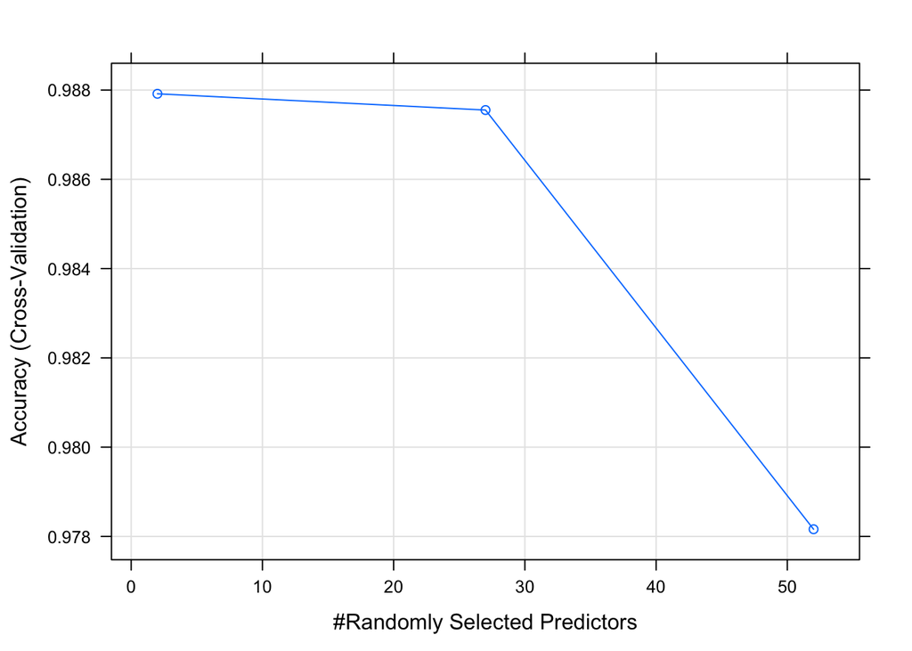

```r
#plot the model
plot(randomForest)
```

Again validation is done using the test dataset

```r
predictRandomForest <- predict(randomForest, newdata=test)
CM_RandomForest <- confusionMatrix(predictRandomForest, test$classe)
CM_RandomForest
```

```
## Confusion Matrix and Statistics
##
##           Reference
## Prediction    A    B    C    D    E
##          A 1674    3    0    0    0
##          B    0 1130   15    0    0
##          C    0    6 1010   14    0
##          D    0    0    1  949    1
##          E    0    0    0    1 1081
##
## Overall Statistics
##
##                Accuracy : 0.993
##                  95% CI : (0.9906, 0.995)
##     No Information Rate : 0.2845
##     P-Value [Acc > NIR] : < 2.2e-16
##
##                   Kappa : 0.9912
##
##  Mcnemar's Test P-Value : NA
##
## Statistics by Class:
##
##                      Class: A Class: B Class: C Class: D Class: E
## Sensitivity            1.0000   0.9921   0.9844   0.9844   0.9991
## Specificity            0.9993   0.9968   0.9959   0.9996   0.9998
## Pos Pred Value         0.9982   0.9869   0.9806   0.9979   0.9991
## Neg Pred Value         1.0000   0.9981   0.9967   0.9970   0.9998
## Prevalence             0.2845   0.1935   0.1743   0.1638   0.1839
## Detection Rate         0.2845   0.1920   0.1716   0.1613   0.1837
## Detection Prevalence   0.2850   0.1946   0.1750   0.1616   0.1839
## Balanced Accuracy      0.9996   0.9945   0.9901   0.9920   0.9994
```

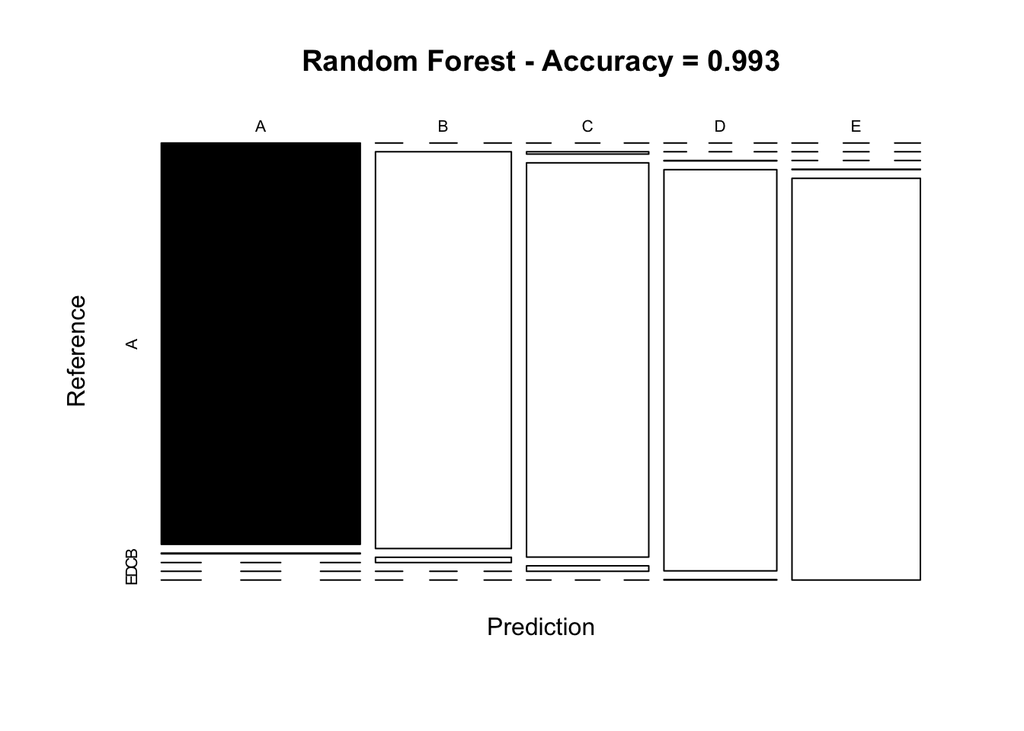

```r
# plot matrix results
plot(CM_RandomForest$table, col = CM_RandomForest$byClass,
     main = paste("Random Forest - Accuracy =",
     round(CM_RandomForest$overall['Accuracy'], 4)))
```

# Generalized Boosted Model

```r
# model fit
set.seed(12345)
GBM_control <- trainControl(method = "repeatedcv", number = 5, repeats = 1)
GBM  <- train(classe ~ ., data=train, method = "gbm",
        trControl = GBM_control, verbose = FALSE)
GBM$finalModel
```

```
## A gradient boosted model with multinomial loss function.
## 150 iterations were performed.
## There were 52 predictors of which 52 had non-zero influence.
```

```r
# prediction on Test dataset
GBM_pred <- predict(GBM, newdata=test)
CM_GBM <- confusionMatrix(GBM_pred, test$classe)
CM_GBM
```

```
## Confusion Matrix and Statistics
##
##           Reference
## Prediction    A    B    C    D    E
##          A 1650   26    1    2    1
##          B   17 1091   35    3   12
##          C    5   20  979   26   11
##          D    1    2   11  928   10
##          E    1    0    0    5 1048
##
## Overall Statistics
##
##                Accuracy : 0.9679
##                  95% CI : (0.9631, 0.9722)
##     No Information Rate : 0.2845
##     P-Value [Acc > NIR] : < 2.2e-16
##
##                   Kappa : 0.9594
##
##  Mcnemar's Test P-Value : 1.749e-05
##
## Statistics by Class:
##
##                      Class: A Class: B Class: C Class: D Class: E
## Sensitivity            0.9857   0.9579   0.9542   0.9627   0.9686
## Specificity            0.9929   0.9859   0.9872   0.9951   0.9988
## Pos Pred Value         0.9821   0.9421   0.9404   0.9748   0.9943
## Neg Pred Value         0.9943   0.9898   0.9903   0.9927   0.9930
## Prevalence             0.2845   0.1935   0.1743   0.1638   0.1839
## Detection Rate         0.2804   0.1854   0.1664   0.1577   0.1781
## Detection Prevalence   0.2855   0.1968   0.1769   0.1618   0.1791
## Balanced Accuracy      0.9893   0.9719   0.9707   0.9789   0.9837
```

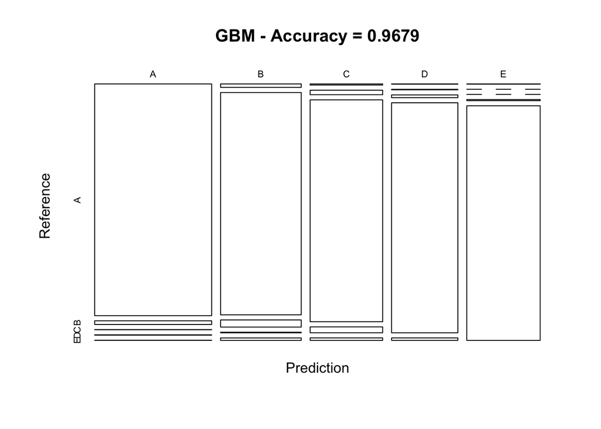

```r
# plot matrix results
plot(CM_GBM$table, col = CM_GBM$byClass,
     main = paste("GBM - Accuracy =", round(CM_GBM$overall['Accuracy'], 4)))
```

## Conclusion

There were three algorithms used for predictive modelling. These were Decision Trees, Random Forests, and global boosting method. Since the Random Forest Algorithm had the best accuracy, it will be used for validation using the test data set.

```r
testPrediction <- predict(randomForest, newdata=ClnTestData1)
testPrediction
```

```
##  [1] B A B A A E D B A A B C B A E E A B B B
## Levels: A B C D E
```